# project-1-checkpoint4

Author

Ruben Jimenez

```r
# load data and libraries
library(tidyverse)
library(ggridges)
library(ggrepel)
library(tidyverse)
library(car)
library(pscl)
library(gt)
library(broom)
library(MASS)

measles_final <- read_csv(here::here("data", "measles_final.csv"))
```

## Visualizations

### Average MCV1 Coverage

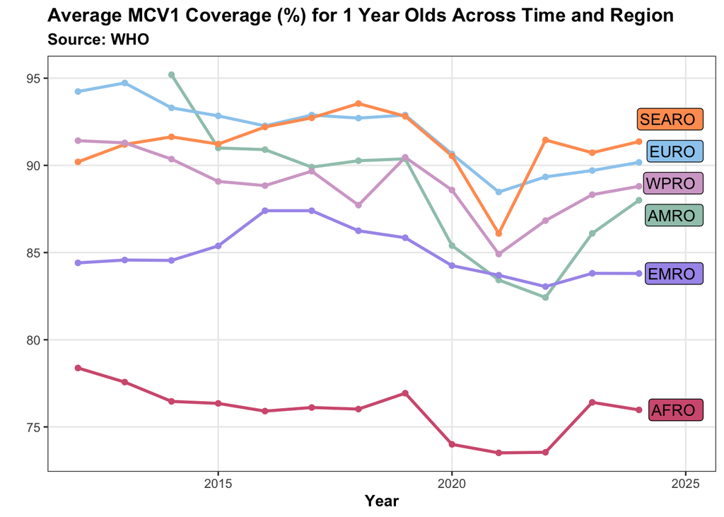

```r
# grab label data
label_data <- measles_final |>
  group_by(Region, Year) |>
  summarise(mean_coverage = mean(`MCV1 Coverage`, na.rm = TRUE),
            .groups = "drop") |>
  drop_na() |>
  group_by(Region) |>
  slice_max(Year) |>
  arrange(mean_coverage)

# make plot
mcv1_plot <- measles_final |>
  group_by(Region, Year) |>
  summarise(mean_coverage = mean(`MCV1 Coverage`, na.rm = TRUE),
            .groups = "drop") |>

  ggplot(aes(x = Year,
             y = mean_coverage,
             color = Region)) +
  geom_line(linewidth = 1) +
  geom_point() +

  # labels
  labs(title = "Average MCV1 Coverage (%) for 1 Year Olds Across Time and Region",
       subtitle = "Source: WHO",
       y = "",
       x = "Year",
       alt = paste("The average measles vaccine coverage is substantially lower for countries in Africa than other regions. We also see a dip in coverage globally around the start of the Covid pandemic.")) +

  # unique colors
  scale_color_manual(values = c("AFRO" = "#d35e7f",
                                  "AMRO" = "#9fc7b9",
                                  "EMRO" = "#a999eb",
                                  "EURO" = "#9bcdef",
                                  "SEARO" = "#ff9d60",
                                  "WPRO" = "#d4a9ce")) +
  scale_fill_manual(values = c("AFRO" = "#d35e7f",
                                  "AMRO" = "#9fc7b9",
                                  "EMRO" = "#a999eb",
                                  "EURO" = "#9bcdef",
                                  "SEARO" = "#ff9d60",
                                  "WPRO" = "#d4a9ce")) +

  # edit graph
  theme_bw() +
  theme(panel.grid.minor = element_blank(),
        plot.title = element_text(face = "bold"),
        plot.subtitle = element_text(face = "bold"),
        legend.title = element_text(face = "bold"),
        axis.title = element_text(face = "bold"),
        legend.position = "none") +

  # move labels
  geom_label_repel(data = label_data,
                  aes(x = Year, y = mean_coverage,
                      label = Region, fill = Region),
                      inherit.aes = FALSE,
                      nudge_x = 1,
                      direction = "y",
                      hjust = 0,
                      segment.color = NA) +

  # expand grid
  expand_limits(x = max(label_data$Year) + 1)

mcv1_plot
```

```r
get_alt_text(mcv1_plot)
```

```
[1] "The average measles vaccine coverage is substantially lower for countries in Africa than other regions. We also see a dip in coverage globally around the start of the Covid pandemic."
```

### Measles Cases Heat Map

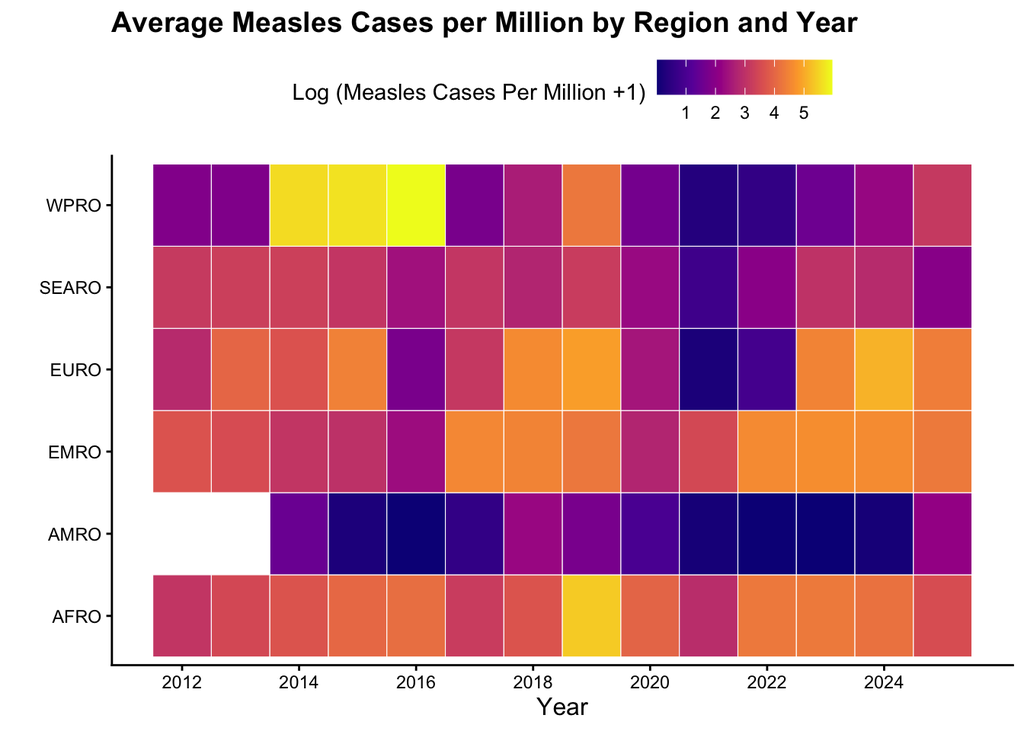

```r
measles_heatmap <- measles_final |>
  group_by(Region, Year) |>
  summarise(mean_cases = mean(`Total Measles per Million`, na.rm = TRUE),
            .groups = "drop") |>

  # compute log(1+x) since we 0s
  ggplot(aes(x = Year,
             y = Region,
             fill = log1p(mean_cases))) +
  geom_tile(color = "white") +

  # non-default colors
  scale_fill_viridis_c(option = "C") + guides(fill = guide_colorbar(direction = "horizontal")) +

  # non-default theme
  theme_classic() +
  theme(plot.title = element_text(face = "bold", size = 14),
        axis.title = element_text(size = 12),
        legend.position = "top") +

  # labels and alt text
  labs(title = "Average Measles Cases per Million by Region and Year",
       x = "Year",
       y = "",
       fill = "Log (Measles Cases Per Million +1)",
       alt = paste("The AMRO region does not have data for 2012 and 2013. The heatmap indicates that there was a measles outbreak from 2014-2016 in the WPRO region. AFRO seems to have relatively consistent measles cases over time, with a spike in 2019.")) +
  scale_x_continuous(breaks = seq(min(measles_final$Year),
                                  max(measles_final$Year),
                                  by = 2))

measles_heatmap
```

```r
get_alt_text(measles_heatmap)
```

```
[1] "The AMRO region does not have data for 2012 and 2013. The heatmap indicates that there was a measles outbreak from 2014-2016 in the WPRO region. AFRO seems to have relatively consistent measles cases over time, with a spike in 2019."
```

## Statistical Model

Since Total Measles Cases can be modeled as count data, we first implemented a null Poisson generalized linear regression model. We aimed to maximize negative log-likelihood through the iterative addition of year-level predictor variables. While initially including population density, primary religion, nominal gdp per capita, region, year, and measles vaccine coverage as our predictors, we found that religion and region were highly multicollinear according to their variance inflation factor, meaning most of the variability in total measles cases from religion could be explained by the region. Our final model included population density, nominal gdp per capita, region, year, and MCV1 coverage, and used a negative binomial model rather than Poisson due to detected overdispersion.

### Candidate Models

```r
# scaling and centering
model_data <- measles_final |>
  mutate(cPopDensity = scale(`Density`, scale = F),
         cNomGDP = scale(`Nominal GDP per Capita`, scale = F),
         cYear = scale(Year, scale = F),
         cMCV1 = scale(`MCV1 Coverage`, scale = F))
```

```r
# null model
m0 <- glm(`Total Measles` ~ 1,
          family = poisson(link = "log"),
          data = model_data)

# model 1
m1 <- glm(`Total Measles` ~ cPopDensity + `Primary Religion` +
            cNomGDP + Region + cYear + cMCV1,
          family = poisson(link = "log"),
          data = model_data)

# model 2
m2 <- glm(`Total Measles` ~ cPopDensity + Region + cYear + cMCV1,
          family = poisson(link = "log"),
          data = model_data)

# model 3
m3 <- zeroinfl(`Total Measles` ~ cPopDensity + Region + cMCV1,
               dist = "poisson",
               data = model_data)

# model 4
m4 <- glm(`Total Measles` ~ cPopDensity + cNomGDP + Region +
          cYear + cMCV1,
          family = poisson(link = "log"),
          data = model_data)

# model 5
m5 <- glm.nb(`Total Measles` ~ cPopDensity + cNomGDP + Region +
               cYear + cMCV1,
             data = model_data)
odTest(m5)
```

[output not shown]

### Candidate Summaries

```r
# summaries
# null model
tidy(m0) |>
  gt()
```

| term | estimate | std.error | statistic | p.value |
| --- | --- | --- | --- | --- |
| (Intercept) | 7.169447 | 0.000568584 | 12609.3 | 0 |

```r
# model 2
tidy(m1) |>
  gt()
```

| term | estimate | std.error | statistic | p.value |
| --- | --- | --- | --- | --- |
| (Intercept) | 6.032460e+00 | 5.871758e-03 | 1027.368621 | 0.000000e+00 |
| cPopDensity | 8.263364e-04 | 3.226777e-06 | 256.087233 | 0.000000e+00 |
| `Primary Religion`catholicism | -1.611662e+00 | 4.702152e-02 | -34.274979 | 1.851922e-257 |
| `Primary Religion`christianity | 2.305650e-01 | 5.656922e-03 | 40.758027 | 0.000000e+00 |
| `Primary Religion`hinduism | 2.680990e+00 | 4.727166e-03 | 567.145272 | 0.000000e+00 |
| `Primary Religion`irreligion | -4.431334e+00 | 1.314393e-01 | -33.713924 | 3.613812e-249 |
| `Primary Religion`islam | 4.500334e-01 | 5.629829e-03 | 79.937321 | 0.000000e+00 |
| `Primary Religion`lutheranism | -1.742923e+00 | 1.024161e-01 | -17.018064 | 6.033281e-65 |
| `Primary Religion`no religion | 2.256604e-02 | 1.402344e-02 | 1.609165 | 1.075802e-01 |
| `Primary Religion`other | -1.033014e+00 | 1.367422e-02 | -75.544638 | 0.000000e+00 |
| `Primary Religion`roman catholicism | -1.102198e-01 | 2.048882e-02 | -5.379509 | 7.468918e-08 |
| `Primary Religion`sunni islam | 5.815213e-02 | 7.420873e-03 | 7.836292 | 4.640467e-15 |
| cNomGDP | -5.277949e-05 | 1.339543e-07 | -394.011017 | 0.000000e+00 |
| RegionAMRO | -1.230014e+00 | 4.624737e-03 | -265.964078 | 0.000000e+00 |
| RegionEMRO | 4.814692e-01 | 2.337338e-03 | 205.990349 | 0.000000e+00 |
| RegionEURO | 6.462311e-01 | 2.220887e-03 | 290.978829 | 0.000000e+00 |
| RegionSEARO | 5.194946e-01 | 3.645943e-03 | 142.485674 | 0.000000e+00 |
| RegionWPRO | -2.298020e+00 | 1.747904e-02 | -131.472880 | 0.000000e+00 |
| cYear | 4.784071e-02 | 1.803884e-04 | 265.209477 | 0.000000e+00 |
| cMCV1 | -3.515180e-02 | 4.324533e-05 | -812.846044 | 0.000000e+00 |

```r
# model 2
tidy(m2) |>
  gt()
```

| term | estimate | std.error | statistic | p.value |
| --- | --- | --- | --- | --- |
| (Intercept) | 6.9450354765 | 1.241965e-03 | 5591.97510 | 0 |
| cPopDensity | -0.0001160207 | 1.333002e-06 | -87.03716 | 0 |
| RegionAMRO | -1.7347200286 | 4.506241e-03 | -384.95944 | 0 |
| RegionEMRO | 0.4071557815 | 1.806801e-03 | 225.34623 | 0 |
| RegionEURO | -0.1073755294 | 1.845941e-03 | -58.16845 | 0 |
| RegionSEARO | 1.5923034497 | 1.803370e-03 | 882.95970 | 0 |
| RegionWPRO | 0.2761938668 | 1.924284e-03 | 143.53069 | 0 |
| cYear | 0.0207678798 | 1.568244e-04 | 132.42759 | 0 |
| cMCV1 | -0.0290532405 | 3.439590e-05 | -844.67168 | 0 |

```r
# model 3 (no tidy() method for zero infl models)
summary(m3)
```

```
Call:
zeroinfl(formula = `Total Measles` ~ cPopDensity + Region + cMCV1, data = model_data,
    dist = "poisson")

Pearson residuals:
     Min       1Q   Median       3Q      Max
 -8.1865  -3.0630  -1.8612  -0.5747 402.0839

Count model coefficients (poisson with log link):
             Estimate Std. Error z value Pr(>|z|)
(Intercept)  6.972321         NA      NA       NA
cPopDensity -0.000132         NA      NA       NA
RegionAMRO  -0.273231         NA      NA       NA
RegionEMRO   0.391316         NA      NA       NA
RegionEURO   0.129939         NA      NA       NA
RegionSEARO  1.736293         NA      NA       NA
RegionWPRO   0.899262         NA      NA       NA
cMCV1       -0.029163         NA      NA       NA

Zero-inflation model coefficients (binomial with logit link):
              Estimate Std. Error z value Pr(>|z|)
(Intercept) -2.7259554         NA      NA       NA
cPopDensity -0.0002228         NA      NA       NA
RegionAMRO   3.8713965         NA      NA       NA
RegionEMRO  -0.7453637         NA      NA       NA
RegionEURO   1.3243881         NA      NA       NA
RegionSEARO  1.3599737         NA      NA       NA
RegionWPRO   2.6167917         NA      NA       NA
cMCV1        0.0073314         NA      NA       NA

Number of iterations in BFGS optimization: 34
Log-likelihood: -5.639e+06 on 16 Df
```

```r
# model 4
tidy(m4) |>
  gt()
```

| term | estimate | std.error | statistic | p.value |
| --- | --- | --- | --- | --- |
| (Intercept) | 6.294467e+00 | 1.710173e-03 | 3680.6033 | 0 |
| cPopDensity | 3.427874e-04 | 2.419054e-06 | 141.7031 | 0 |
| cNomGDP | -5.514441e-05 | 9.987802e-08 | -552.1176 | 0 |
| RegionAMRO | -1.352895e+00 | 4.524747e-03 | -298.9990 | 0 |
| RegionEMRO | 6.293257e-01 | 1.814715e-03 | 346.7904 | 0 |
| RegionEURO | 7.370082e-01 | 2.036865e-03 | 361.8347 | 0 |
| RegionSEARO | 1.617696e+00 | 1.881558e-03 | 859.7642 | 0 |
| RegionWPRO | 1.304840e+00 | 2.740118e-03 | 476.1983 | 0 |
| cYear | 3.690434e-02 | 1.658731e-04 | 222.4854 | 0 |
| cMCV1 | -2.886110e-02 | 4.015589e-05 | -718.7263 | 0 |

```r
# model 5
tidy(m5) |>
  gt()
```

| term | estimate | std.error | statistic | p.value |
| --- | --- | --- | --- | --- |
| (Intercept) | 5.602075e+00 | 1.190263e-01 | 47.065866 | 0.000000e+00 |
| cPopDensity | -1.887564e-03 | 2.343059e-04 | -8.055980 | 7.884428e-16 |
| cNomGDP | -3.028494e-05 | 3.156449e-06 | -9.594626 | 8.422237e-22 |
| RegionAMRO | -4.282527e-01 | 1.893021e-01 | -2.262271 | 2.368066e-02 |
| RegionEMRO | 1.104134e+00 | 1.923359e-01 | 5.740655 | 9.431078e-09 |
| RegionEURO | 1.394011e+00 | 1.747190e-01 | 7.978586 | 1.480190e-15 |
| RegionSEARO | 3.244598e+00 | 2.585396e-01 | 12.549713 | 3.989536e-36 |
| RegionWPRO | 2.654603e+00 | 2.892528e-01 | 9.177450 | 4.414211e-20 |
| cYear | 6.150761e-02 | 1.532001e-02 | 4.014854 | 5.948249e-05 |
| cMCV1 | -5.747727e-02 | 4.651144e-03 | -12.357662 | 4.428516e-35 |

### Candidate Log Likelihoods

```r
# model 1
logLik(m1)
```

```
'log Lik.' -3904909 (df=20)
```

```r
# model 2
logLik(m2)
```

```
'log Lik.' -6289058 (df=9)
```

```r
# model 3
logLik(m3)
```

```
'log Lik.' -5638556 (df=16)
```

```r
# model 4
logLik(m4)
```

```
'log Lik.' -5130611 (df=10)
```

```r
# model 5
logLik(m5)
```

```
'log Lik.' -11228.3 (df=11)
```

### Candidate VIFs

```r
# model 1
vif(m1)
```

```
                        GVIF Df GVIF^(1/(2*Df))
cPopDensity         1.579768  1        1.256888
`Primary Religion`  9.060647 10        1.116498
cNomGDP             1.784373  1        1.335804
Region             12.631698  5        1.288683
cYear               1.018986  1        1.009448
cMCV1               1.571796  1        1.253713
```

```r
# model 2
vif(m2)
```

```
                GVIF Df GVIF^(1/(2*Df))
cPopDensity 1.068957  1        1.033904
Region      1.260567  5        1.023426
cYear       1.016643  1        1.008287
cMCV1       1.271982  1        1.127822
```

```r
# model 4
vif(m4)
```

```
                GVIF Df GVIF^(1/(2*Df))
cPopDensity 1.330525  1        1.153484
cNomGDP     1.416436  1        1.190141
Region      1.915575  5        1.067161
cYear       1.022200  1        1.011039
cMCV1       1.460875  1        1.208667
```

### Final Model

Based on the results of model fitting, we found that Southeast Asia has the greatest mean number of measles cases annually after adjusting for population density, nominal GDP per capita, year, and MCV1 coverage. The Americas have the lowest mean number of measles cases annually after adjusting for population density, nominal GDP per capita, year, and MCV1 coverage. Population density has a negative effect on mean measles cases after adjusting for the other variables, while nominal GDP per capita has a small negative effect on mean measles cases after adjusting for the other variables. Increases in year are associated with an increase in the mean number of measles cases after adjusting for the other variables. MCV1 coverage, or vaccination rate, has the largest negative effect on mean measles cases after adjusting for the other variables.

```r
tidy(m5) |>
  mutate(term = str_replace_all(term, c("Region" = "",
                                        "cPopDensity" = "Pop. Density*",
                                        "cNomGDP" = "Nominal GDP per Capita*",
                                        "cYear" = "Year*",
                                        "cMCV1" = "MCV1 Coverage*",
                                        "\\(|\\)" = ""))) |>
  rename("Model Term" = "term",
         "Estimate" = "estimate",
         "Std. Error" = "std.error",
         "Z-Statistic" = "statistic",
         "p-value" = "p.value") |>
  gt() |>
  fmt_number(decimals = 3) |>
  tab_header(
    title = md("**NB GLM Coefficients**")) |>
  tab_style(
    style = cell_text(weight = "bold"),
    locations = cells_column_labels(everything())) |>
  tab_caption("Table 1: Negative Binomial regression results. Response measures total measles cases across a region in a given year. Baseline region is Africa.") |>
  tab_footnote("*Quantitative variables are centered for interpretability")
```

Table 1: Negative Binomial regression results. Response measures total measles cases across a region in a given year. Baseline region is Africa.

**NB GLM Coefficients**

| Model Term | Estimate | Std. Error | Z-Statistic | p-value |
| --- | --- | --- | --- | --- |
| Intercept | 5.602 | 0.119 | 47.066 | 0.000 |
| Pop. Density* | −0.002 | 0.000 | −8.056 | 0.000 |
| Nominal GDP per Capita* | 0.000 | 0.000 | −9.595 | 0.000 |
| AMRO | −0.428 | 0.189 | −2.262 | 0.024 |
| EMRO | 1.104 | 0.192 | 5.741 | 0.000 |
| EURO | 1.394 | 0.175 | 7.979 | 0.000 |
| SEARO | 3.245 | 0.259 | 12.550 | 0.000 |
| WPRO | 2.655 | 0.289 | 9.177 | 0.000 |
| Year* | 0.062 | 0.015 | 4.015 | 0.000 |
| MCV1 Coverage* | −0.057 | 0.005 | −12.358 | 0.000 |

*Quantitative variables are centered for interpretability